# Denoising with tvR package

Kisung You

For a given noisy signal $f$, total variation regularization (also known as denoising) aims at recovering a *cleaned* version of signal $u$ by solving an equation of the following form
$$\min_u ~ E(u,f) + \lambda V(u)$$
where $E(u,f)$ is a fidelity term that measures closeness of noisy signal $f$ to a desired solution $u$, and $V(u)$ a penalty term in pursuit of smoothness of a solution. For a differentiable function $u : \Omega\rightarrow \mathbb{R}$, total variation is defined as
$$V(u) = \int_{\Omega} \| \nabla u(x) \| dx$$
and $\lambda$ a regularization parameter that balances fitness and smoothness defined by two terms.

Our **tvR** package provides two functions

- `denoise1` for 1d signal (usually with time domain), and
- `denoise2` for 2d signal such as image.

Let’s see two examples in the below.

```r
library(tvR)
```

[output not shown]

### Example : 1d signal with `denoise1`

We aim to solve TV-L2 problem, where
$$E(u,f) = \frac{1}{2} \int |u(x) - f(x)|^2 dx$$
with a penalty $V(u) = \sum_i |u_{i+1}-u_{i}|$ with two algorithms, including 1) iterative clippling algorithm and 2) majorization-minorization method.

As an example, let’s create a stepped signal and add gaussian white noise with $\sigma = 0.25$

```r
set.seed(1)
x = rep(sample(1:5,10,replace=TRUE), each=50) ## main signal
xnoised = x + rnorm(length(x), sd=0.25)       ## add noise
```

First, let’s compare how two algorithms perform with $\lambda=1.0$.

```r
## apply denoising process
xproc1 = denoise1(xnoised, method = "TVL2.IC")
xproc2 = denoise1(xnoised, method = "TVL2.MM")
```

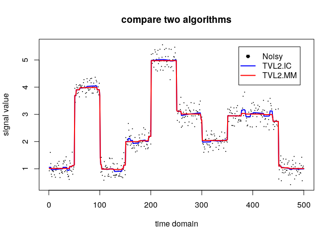

which shows somewhat seemingly inconsistent results. However, this should be understood as induced by their internal algorithmic details such as stopping criterion. In such sense, let’s compare whether a single method is consistent with respect to the degree of regularization by varying parameters $\lambda=10^{-3}, 10^{-2}, 10^{-1}, 1$. For this comparison, we will use iterative clipping (`TVL2.IC`) algorithm.

```r
compare = list()
for (i in 1:4){
  compare[[i]] = denoise1(xnoised, lambda = 10^(i-4), method="TVL2.IC")
}
```

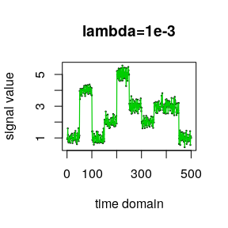

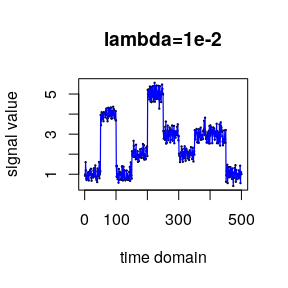

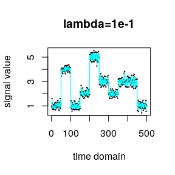

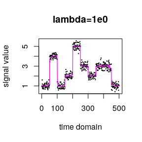

An observation can be made that the larger the $\lambda$ is, the smoother the fitted solution becomes.

### Example : image denoising with `denoise2`

For a 2d signal case, we support both *TV-L1* and *TV-L2* problem, where
$$E_{L_1}(u,f) = \int_\Omega |u(x) - f(x)|_1 dx \\
E_{L_2}(u,f) = \int_\Omega |u(x) - f(x)|_2^2 dx$$
given a 2-dimensional domain $\Omega \subset \mathbb{R}^2$ and a penalty $V(u) = \sum (u_x^2 + u_y^2)^{1/2}$. For *TV-L1* problem, we provide primal-dual algorithm, whereas *TV-L2* brings primal-dual algorithm as well as finite-difference scheme with fixed point iteration.

A typical yet major example of 2-dimensional signal is **image**, considering each pixel’s value as $f(x,y)$ at location $(x,y)$. We’ll use the gold standard image of [Lena](https://en.wikipedia.org/wiki/Lenna). In our example, we will use a version of gray-scale Lena image stored as a matrix of size $128 \times 128$ and add some gaussian noise as before with $\sigma=10$.

```r
data(lena128)
xnoised <- lena128 + array(rnorm(128*128, sd=10), c(128,128))
```

Let’s see how different algorithms perform with $\lambda=10$.

```r
## apply denoising process
xproc1 <- denoise2(xnoised, lambda=10, method="TVL1.PrimalDual")
xproc2 <- denoise2(xnoised, lambda=10, method="TVL2.FiniteDifference")
xproc3 <- denoise2(xnoised, lambda=10, method="TVL2.PrimalDual")
```

[figure not shown]

[figure not shown]

[figure not shown]

[figure not shown]